# Assignment 9

Erin Gunduz

11/3/2018

# Batch Effects Exercise 1:

### Excercise Introduction: Load the admissions data from the dagdata package (which is available from the genomicsclass repository):

```r
library(devtools)
#install_github("genomicsclass/dagdata")
library(dagdata)
data(admissions)

#Familiarize yourself with this table:
admissions
```

```
##    Major Number Percent Gender
## 1      A    825      62      1
## 2      B    560      63      1
## 3      C    325      37      1
## 4      D    417      33      1
## 5      E    191      28      1
## 6      F    373       6      1
## 7      A    108      82      0
## 8      B     25      68      0
## 9      C    593      34      0
## 10     D    375      35      0
## 11     E    393      24      0
## 12     F    341       7      0
```

### 1: Let’s compute the proportion of men who were accepted:

```r
index = which(admissions$Gender==1)
accepted= sum(admissions$Number[index] * admissions$Percent[index]/100)
applied = sum(admissions$Number[index])
accepted/applied
```

```
## [1] 0.4451951
```

### What is the proportion of women that were accepted?

```r
index = which(admissions$Gender==0)
accepted = sum(admissions$Number[index] * admissions$Percent[index]/100)
applied = sum(admissions$Number[index])
accepted/applied
```

```
## [1] 0.3033351
```

### 2: Now that we have observed different acceptance rates between genders, test for the significance of this result. If you perform an independence test, what is the p-value?

```r
#This difference actually led to a lawsuit. Now notice that looking at the data by major, the differences disappear.
admissions
```

```
##    Major Number Percent Gender
## 1      A    825      62      1
## 2      B    560      63      1
## 3      C    325      37      1
## 4      D    417      33      1
## 5      E    191      28      1
## 6      F    373       6      1
## 7      A    108      82      0
## 8      B     25      68      0
## 9      C    593      34      0
## 10     D    375      35      0
## 11     E    393      24      0
## 12     F    341       7      0
```

### How can this be? This is referred to as Simpson’s Paradox. In the following questions we will try to decipher why this is happening.

```r
#I created a table that has the totals for accepted and not-accepted by gender then used a chisq.test:
atab<-as.data.frame(matrix(0,2,2))
rownames(atab)<-c("Men","Women")
colnames(atab)<-c("Accepted","Rejected")
index = admissions$Gender==1
men=admissions[index,]
women=admissions[!index,]
atab[1,1]= sum(men$Number * men$Percent/100)
atab[1,2]= sum(men$Number*(1-men$Percent/100))
windex = which(admissions$Gender==0)
atab[2,1]= sum(women$Number * women$Percent/100)
atab[2,2]= sum(women$Number * (1-women$Percent/100))
atab
```

```
##       Accepted Rejected
## Men    1198.02  1492.98
## Women   556.62  1278.38
```

```r
chisq.test(atab)$p.value
```

```
## [1] 9.139492e-22
```

```r
#Looking at the data based on major:
index = admissions$Gender==1
men = admissions[index,]
women = admissions[!index,]
print( data.frame( major=admissions[1:6,1],men=men[,3], women=women[,3]) )
```

```
##   major men women
## 1     A  62    82
## 2     B  63    68
## 3     C  37    34
## 4     D  33    35
## 5     E  28    24
## 6     F   6     7
```

##### From the first computation looking at the data based on gender, the p-value was 9.139492e-22.

### 3: We can quantify how “hard” a major is by using the percent of students that were accepted. Compute the percent that were accepted (regardless of gender) to each major and call this vector H. Which is the hardest major?

```r
major = admissions[1:6,1]
men = admissions[1:6,]
women =admissions[7:12,]
H = (men$Number*men$Percent/100 + women$Number*women$Percent/100) / (men$Number+women$Number)
H
```

```
## [1] 0.64315113 0.63213675 0.35062092 0.33946970 0.25308219 0.06477591
```

```r
major[which.min(H)]
```

```
## [1] F
## Levels: A B C D E F
```

##### From this, we can see that the hardest major is “F” out of the different levels. It is classified as the hardest major based on the percentage of students that were accepted (regardless of gender). Therefore, major F had the lowest proportion of students that were accepted and is hence the “hardest” major.

### 4: What proportion is accepted for this major?

```r
min(H)
```

```
## [1] 0.06477591
```

##### From the table in question 3 and the computation above, the proportion accepted for this major is 0.06477591.

### 5: For men, what is the correlation between the number of applications across majors and H?

```r
cor(H,men$Number)
```

```
## [1] 0.7647567
```

```r
cor(men$Number,H) # same!
```

```
## [1] 0.7647567
```

##### The correlation between the number of applications across majors and H, for men, is 0.7647567.

### 6: For women, what is the correlation between the number of applications across majors and H?

```r
cor(H,women$Number)
```

```
## [1] -0.6743393
```

```r
cor(women$Number,H) # same!
```

```
## [1] -0.6743393
```

##### The correlation between the number of applications across majors and H, for women, is -0.6743393.

### 7: Given the answers to the above, which best explains the differences in admission percentages when we combine majors?

#### A) We made a coding mistake when computing the overall admissions percentages.

#### B) There were more total number of women applications which made the denominator much bigger.

#### C) There is confounding between gender and preference for “hard” majors: females are more likely to apply to harder majors.

#### D) The sample size for the individual majors was not large enough to draw the correct conclusion.

##### The answer that best explains the differences in admission percentages when we combine majors is C) There is a confounding between gender and preference for “hard” majors: females are more likely to apply to harder majors. This is because, when we computed the correlation between the number of applications across majors and H, for women we got a negative correlation, meaning that a decrease in application of majors is associated with an increase in applications of H. This is an inverse relationship and it is contrasted with the correlation calculated for men (which was positive). Hence, the correct answer is that there is a confounding between gender and preference, which essentially means that women are more likely to apply to harder majors than men. Similarly, if you were to generate a plot of the percentages that applied to majors against the percentages that got into that major, for males and females, it would show that women were more likely to apply to “hard” majors. Therefore, it would demonstrate that females and “hard” majrs are confounded.

### #Batch Effects Exercise 2:

### Excercise Introduction: We will use the Bioconductor package Biobase which you can install with install_bioc function from rafalib:

```r
#Load the data for this gene expression dataset:
library(devtools)
install_github("genomicsclass/GSE5859")
```

```
## Skipping install of 'GSE5859' from a github remote, the SHA1 (3d8cdd75) has not changed since last install.
##   Use `force = TRUE` to force installation
```

```r
library(Biobase)
library(GSE5859)
data(GSE5859)

#This is the original dataset from which we selected the subset used in GSE5859Subset. We can extract the gene expression data and sample information table using the Bioconductor functions exprs and pData like this:
geneExpression = exprs(e)
sampleInfo = pData(e)
```

### 1: Familiarize yourself with the sampleInfo table. Note that some samples were processed at different times. This is an extraneous variable and should not affect the values in geneExpression. However, as we have seen in previous analyses, it does appear to have an effect so we will explore this here.

```r
#You can extract the year from each date like this:
year = format(sampleInfo$date,"%y")

#Note that ethnic group and year is almost perfectly confounded:
table(year,sampleInfo$ethnicity)
```

```
##
## year ASN CEU HAN
##   02   0  32   0
##   03   0  54   0
##   04   0  13   0
##   05  80   3   0
##   06   2   0  24
```

```r
#The number of unique years for which we have data is:
length(unique(year))
```

```
## [1] 5
```

##### There are 5 unique years for which we have data.

### 2: For how many of these years do we have more than one ethnicity represented?

```r
tab = table(year, sampleInfo$ethnicity)
print(tab)
```

```
##
## year ASN CEU HAN
##   02   0  32   0
##   03   0  54   0
##   04   0  13   0
##   05  80   3   0
##   06   2   0  24
```

```r
x = rowSums(tab != 0)
sum(x >= 2)
```

```
## [1] 2
```

##### As seen in the computation above, there are 2 years for which there is more than one ethnicity represented.

### 3: Repeat the above exercise, but now, instead of year, consider the month as well. Specifically, instead of the year variable defined above use:

```r
month.year = format(sampleInfo$date,"%m%y")
```

### For what proportion of these month.year values do we have more than one ethnicity represented?

```r
mytab = table(month.year, sampleInfo$ethnicity)
print(mytab)
```

```
##
## month.year ASN CEU HAN
##       0103   0  27   0
##       0203   0  18   0
##       0205   0   2   0
##       0303   0   7   0
##       0403   0   2   0
##       0404   0   4   0
##       0406   0   0  24
##       0505   2   0   0
##       0605  22   1   0
##       0606   2   0   0
##       0705   6   0   0
##       0805  12   0   0
##       0905   6   0   0
##       1002   0   2   0
##       1005  16   0   0
##       1102   0  15   0
##       1104   0   7   0
##       1105  13   0   0
##       1202   0  15   0
##       1204   0   2   0
##       1205   3   0   0
```

```r
myx = rowSums(mytab != 0)
mean(myx >= 2)
```

```
## [1] 0.04761905
```

##### As per the computation above, the proportion of these month.year values that there is more than one ethnicity represented is 0.04761905. This value implies that month.year and ethnicity are almost completely confounded, which means that it is hard to separate effects due to date from effects due to our outcome of interest.

### 4: Perform a t-test (use rowttests) comparing CEU samples processed in 2002 to those processed in 2003. Then use the qvalue package to obtain q-values for each gene. How many genes have q-values < 0.05?

```r
library(qvalue)
library(genefilter)
year = factor( format(sampleInfo$date,"%y") )
index = which(year%in% c("02","03") & sampleInfo$ethnicity=="CEU")
year = droplevels(year[index])
pval = rowttests(geneExpression[ ,index], year)$p.value
qval = qvalue(pval)
sum(qval$qvalue < 0.05)
```

```
## [1] 4308
```

##### After performing a t-test, per the computation above, the number of genes with q-value less than 0.05 is 4308.

### 5: What is the estimate of pi0 provided by qvalue:

```r
qval$pi0
```

```
## [1] 0.3628642
```

##### The estimate of pi0 provided by the qvalue is 0.3628642. It’s important to note that the estimated percentage of genes that are differentially expressed is above 50%. This is one way to show the magnitude of the effect processing date has on the measurements.

### 6: Now perform a t-test (use rowttests) comparing CEU samples processed in 2003 to those processed in 2004. Then use the qvalue package to obtain q-values for each gene. How many genes have q-values less than 0.05?

```r
library(qvalue)
library(genefilter)
year = factor( format(sampleInfo$date,"%y") )
index = which(year%in% c("03","04") & sampleInfo$ethnicity=="CEU")
year = droplevels(year[index])
pval = rowttests(geneExpression[ ,index], year)$p.value
qval = qvalue(pval)
sum(qval$qvalue < 0.05)
```

```
## [1] 2463
```

##### From the computation above, we can see that the number of genes with q-value less than 0.05 is 2463. From this we can confirm the processing date has an effect on our measurements.

### 7: Now we are going to compare ethnicities as was done in the original publication in which these data were first presented. Use the qvalue function to compare the ASN population to the CEU population. Once again, use the qvalue function to obtain q-values. How many genes have q-values < 0.05?

```r
library(qvalue)
library(genefilter)
ethnicity = factor(sampleInfo$ethnicity)
index = which(ethnicity %in% c("CEU", "ASN"))
ethnicity = droplevels(ethnicity[index])
pval = rowttests(geneExpression[ ,index], ethnicity)$p.value
qval = qvalue(pval)
sum(qval$qvalue < 0.05)
```

```
## [1] 7217
```

##### From the code above, we can see that the number of genes with q-values less than 0.05 is 7217.

### 8: Over 80% of genes are called differentially expressed between ethnic groups. However, due to the confounding with processing date, we need to confirm these differences are actually due to ethnicity. This will not be easy due to the almost perfect confounding. However, above we noted that two groups were represented in 2005. Just like we stratified by majors to remove the “major effect” in our admissions example, here we can stratify by year and perform a t-test comparing ASN and CEU, but only for samples processed in 2005. How many genes have q-values < 0.05 ?

```r
#Notice the dramatic drop in the number of genes with q-value < 0.05 when we fix the year. However, the sample size is much smaller in this latest analysis which means we have less power:
table(sampleInfo$ethnicity[index])
```

```
##
## ASN CEU HAN
##  82 102   0
```

```r
#How many genes have q-values < 0.05?:
library(qvalue)
library(genefilter)
ethnicity = factor( sampleInfo$ethnicity)
year = factor( format(sampleInfo$date,"%y") )
index = which(ethnicity%in% c("CEU","ASN") & year=="05")
ethnicity = droplevels(ethnicity[index])
pval = rowttests(geneExpression[ ,index], ethnicity)$p.value
qval = qvalue(pval)
sum(qval$qvalue < 0.05)
```

```
## [1] 560
```

##### From the computation above, we can see that the number of genes with q-value less than 0.05 is 560. Here, we can see a dramatic drop in the number of genes with q-value < 0.05 when we fix the year. However, the sample size is much smaller in this latest analysis which means we have less power, as can be seen below:

```r
table(sampleInfo$ethnicity[index])
```

```
##
## ASN CEU HAN
##  80   3   0
```

### 9: To provide a more balanced comparison, we repeat the analysis, but now taking 3 random CEU samples from 2002. Repeat the analysis above, but comparing the ASN from 2005 to three random CEU samples from 2002. Set the seed at 3, set.seed(3). How many genes have q-values < 0.05?

```r
library(qvalue)
library(genefilter)
ethnicity = factor( sampleInfo$ethnicity)
year = factor( format(sampleInfo$date,"%y") )
indexASN = which(ethnicity%in% c("ASN") & year=="05")
indexCEU = which(ethnicity%in% c("CEU") & year=="02")
set.seed(3)
indexCEU<-sample(indexCEU,3)
index<-c(indexASN,indexCEU)
ethnicity = droplevels(ethnicity[index])
pval = rowttests(geneExpression[ ,index], ethnicity)$p.value
qval = qvalue(pval)
sum(qval$qvalue < 0.05)
```

```
## [1] 3695
```

##### Here, in this example, we can see that the number of genes that have a q-value less than 0.05 is 3695.

### #Batch Effects Exercise 3:

```r
#For the dataset we have been working with, models do not help due to the almost perfect confounding. This is one reason we created the subset dataset:
library(GSE5859Subset)
data(GSE5859Subset)

#Here we purposely confounded month and group (sex), but not completely:
sex = sampleInfo$group
month = factor( format(sampleInfo$date,"%m"))
table( sampleInfo$group, month)
```

```
##    month
##     06 10
##   0  9  3
##   1  3  9
```

### 1: Using the functions rowttests and qvalue compare the two groups. Because this is a smaller dataset which decreases our power, we will use the more lenient FDR cut-off of 10%. How many gene have q-values less than 0.1?

```r
library(qvalue)
library(genefilter)
sex = factor( sex)
pval = rowttests(geneExpression, sex)$p.value
qval = qvalue(pval)
sum(qval$qvalue < 0.1)
```

```
## [1] 59
```

##### From the computation above, we can see that the number of genes with q-values less than 0.1 is 59.

### 2: Note that sampleInfo$group here presents males andf emales. Thus, we expect differences to be in on chrY and, for genes that escape inactivation, chrX. We do not expect many autosomal genes to be different between males and females. This gives us an opportunity to evaluate false and true positives with experimental data. For example, we evaluate results using the proportion genes of the list that are on chrX or chrY. For the list calculated above, what proportion of this list is on chrX or chrY?

```r
library(qvalue)
library(genefilter)
sex = factor( sex)
pval = rowttests(geneExpression, sex)$p.value
qval = qvalue(pval)
qvals = qval$qvalues
index = geneAnnotation$CHR[qvals<0.1]%in%c("chrX","chrY")
mean(index)
```

```
## [1] 0.3389831
```

##### From the list of genes with q-value less than 0.1, calculated in #1, the proportion of this list on chrX or chrY is 0.3389831.

### 3: We can also check how many of the chromosomes X and Y genes we detected as different. How many are on Y?

```r
Y = which(geneAnnotation$CHR[index] == "chrY")
Y
```

```
## [1]  886 1267 1566 1569 1638 2024
```

```r
chrY = sum(geneAnnotation$CHR[index] == "chrY", na.rm = TRUE)
chrY
```

```
## [1] 6
```

##### There are 6 genes located on chromosome Y.

### 4: Now for the autosomal genes (not on chrX and chrY) for which q-value < 0.1, perform a t-test comparing samples processed in June to those processed in October. What proportion of these have p-values < 0.05 ?

```r
library(qvalue)
library(genefilter)
sex = factor( sex)
pval = rowttests(geneExpression, sex)$p.value
qval = qvalue(pval)
qvals = qval$qvalues
index = which(qvals<0.1 & !geneAnnotation$CHR%in%c("chrX","chrY"))
month = factor( format(sampleInfo$date,"%m"))
pval = rowttests(geneExpression[index,], month)$p.value
mean(pval<0.05)
```

```
## [1] 0.8717949
```

##### As per the computation above, the proportion of these autosomal genes that have p-values les than 0.05 is 0.8717949.

### 5: The above result shows that the great majority of the autosomal genes show differences due to processing data. This provides further evidence that confounding is resulting in false positives. So we are going to try to model the month effect to better estimate the sex effect. We are going to use a linear model. Which of the following creates the appropriate design matrix?

#### A) X = model.matrix(∼sex+ethnicity)

#### B) X = cbind(sex,as.numeric(month))

#### C) It can’t be done with one line.

#### D) X = model.matrix(∼sex+month)

##### There D) X = model.matrix(~sex+month)

### 6: Now use the X defined above, to fit a regression model using lm for each gene. You can obtain p-values for estimated parameters using summary. Here is an example

```r
X = model.matrix(~sex+month)
i = 234
y = geneExpression[i,]
fit = lm(y~X)
summary(fit)$coef
```

```
##                Estimate Std. Error     t value     Pr(>|t|)
## (Intercept)  9.33316105 0.06098459 153.0412990 1.714250e-33
## Xsex1       -0.04281057 0.09220004  -0.4643227 6.471942e-01
## Xmonth10     0.25352885 0.09220004   2.7497696 1.200505e-02
```

### How many of the q-values for the group comparison are now <0.1? Note the big drop from what we obtained without the correction.

```r
X = model.matrix(~sex+month)
pvals <- t( sapply(1:nrow(geneExpression),function(j){
  y <- geneExpression[j,]
  fit <- lm(y~X-1)
  summary(fit)$coef[2,4] # the 2 picks out the second (sex) coef, the 4 picks out the p value
} ) )

library(qvalue)
library(genefilter)
qval = qvalue(pvals)
qvals = qval$qvalues
sum(qvals<0.1)
```

```
## [1] 17
```

### 7: With this new list, what proportion of these are chrX and chrY? Notice the big improvement.

```r
index1 = geneAnnotation$CHR[qvals<0.1]%in%c("chrX","chrY")
mean(index1)
```

```
## [1] 0.8823529
```

##### The proportion of these that are chrX and chrY is 0.8823529.

### 8: How many on Y or X?

```r
X1 = which(geneAnnotation$CHR[index1] == "chrX")
X1
```

```
##   [1]   68  108  139  178  219  227  277  293  301  313  320  324  352  366
##  [15]  373  406  428  451  496  516  525  529  562  583  622  698  715  724
##  [29]  728  730  740  769  821  879  882  896  914  923  963  986  993 1011
##  [43] 1013 1075 1083 1131 1145 1152 1197 1209 1262 1283 1292 1395 1402 1413
##  [57] 1416 1423 1498 1502 1524 1560 1571 1592 1593 1598 1625 1650 1651 1662
##  [71] 1697 1716 1720 1730 1734 1743 1772 1784 1808 1817 1847 1934 1963 1984
##  [85] 1994 2004 2020 2023 2058 2081 2082 2170 2186 2203 2212 2258 2272 2281
##  [99] 2287 2290 2295 2306 2356 2368 2386 2389 2415 2418 2425 2493 2495 2507
## [113] 2570 2571 2600 2605 2609 2624 2673 2690 2743 2760 2843 2882 2912 2934
## [127] 2973 3002 3003 3016 3019 3050 3051 3052 3118 3153 3158 3178 3205 3245
## [141] 3251 3269 3291 3304 3314 3317 3320 3348 3350 3355 3359 3371 3377 3384
## [155] 3387 3403 3436 3445 3447 3480 3558 3564 3609 3616 3637 3639 3680 3683
## [169] 3694 3708 3717 3730 3733 3736 3755 3762 3779 3783 3791 3795 3797 3809
## [183] 3841 3845 3877 3880 3889 3893 3897 3901 3902 3928 3945 3954 3966 3975
## [197] 3994 3998 4009 4041 4069 4073 4074 4132 4181 4200 4202 4207 4235 4260
## [211] 4270 4279 4307 4311 4322 4337 4445 4482 4489 4548 4597 4599 4632 4667
## [225] 4679 4712 4765 4796 4817 4934 4997 5035 5063 5069 5070 5087 5122 5125
## [239] 5128 5132 5161 5192 5218 5224 5261 5310 5324 5409 5510 5535 5554 5558
## [253] 5606 5668 5674 5675 5677 5710 5747 5811 5815 5819 5821 5833 5838 5855
## [267] 5870 5910 5917 5918 5959 5967 5975 5981 5994 6007 6017 6125 6132 6150
## [281] 6255 6267 6317 6320 6349 6363 6364 6398 6442 6472 6531 6545 6560 6563
## [295] 6590 6593 6601 6603 6679 6688 6706 6713 6722 6759 6775 6790 6800 6812
## [309] 6814 6815 6830 6847 6876 6890 6910 6949 6954 6991 6993 7030 7074 7093
## [323] 7103 7109 7160 7192 7208 7249 7257 7259 7279 7301 7309 7338 7360 7381
## [337] 7423 7447 7465 7477 7489 7491 7495 7515 7533 7539 7587 7590 7591 7598
## [351] 7610 7627 7638
```

```r
chrX1 = sum(geneAnnotation$CHR[index1] == "chrX", na.rm = TRUE)
chrX1
```

```
## [1] 353
```

```r
Y1 = which(geneAnnotation$CHR[index1] == "chrY")
Y1
```

```
##  [1]  734 2305 3302 3352 3397 3497 3713 4075 4085 4091 4231 4259 4273 4285
## [15] 4286 4290 5266
```

```r
chrY1 = sum(geneAnnotation$CHR[index1] == "chrY", na.rm = TRUE)
chrY1
```

```
## [1] 17
```

### 9: Now from the linear model above, extract the p-values related to the coefficient representing the October versus June differences using the same linear model. How many of the q-values for the month comparison are now <0.1? This approach is basically the approach implemented by Combat.

```r
X = model.matrix(~sex+month)

pvals <- t( sapply(1:nrow(geneExpression),function(j){
  y <- geneExpression[j,]
  fit <- lm(y~X-1)
  summary(fit)$coef[3,4] # third coef, for month
} ) )

library(qvalue)
library(genefilter)
qval = qvalue(pvals)
qvals = qval$qvalues
sum(qvals<0.1)
```

```
## [1] 3170
```

##### There are 3170 q-values for the month comparison are now less than 0.1.

### #Batch Effects Exercise 4:

```r
#We will continue to use this dataset:
library(Biobase)
library(GSE5859Subset)
data(GSE5859Subset)
```

### 1: Suppose you want to make an MA plot of the first two samples y=geneExpression[,1:2]. Which of the following projections gives us the projection of y so that column2 versus column 1 is an MA plot?

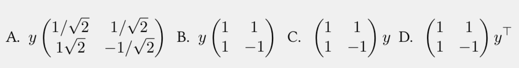

```r
knitr::include_graphics('/Users/Erin/Documents/Screen\ Shot\ 2018-11-03\ at\ 2.05.53\ PM.png')
```

##### The answer is B)

### 2: Say Y is M×N, in the SVD Y = UDV^⊤ which of the following is not correct?

#### A) DV^⊤ are the new coordinates for the projection U^⊤Y

#### B) UD are the new coordinates for the projection YV

#### C) D are the coordinates of the projection U^⊤Y

#### D) U^⊤Y is a projection from an N-dimensional to M-dimensional subspace.

##### The answer is C) D are the coordinates of the projection U^TY.

### 3: Define:

```r
y = geneExpression - rowMeans(geneExpression)
```

### Compute and plot an image of the correlation for each sample. Make two image plots of these correlations. In the first one, plot the correlation as image. In the second, order the samples by date and then plot an image of the correlation. The only difference in these plots is the order in which the samples are plotted. Based on these plots, which of the following you would say is true?

#### A) The samples appear to be completely independent of each other.

#### B) Sex seems to be creating structures as evidenced by the two cluster of highly correlated samples.

#### C) There appear to be only two factors completely driven by month.

#### D) The fact that in the plot ordered by month we see two groups mainly driven by month, and within these we see subgroups driven by date, seems to suggest date more than month per se are the hidden factors.

```r
library(rafalib)
```

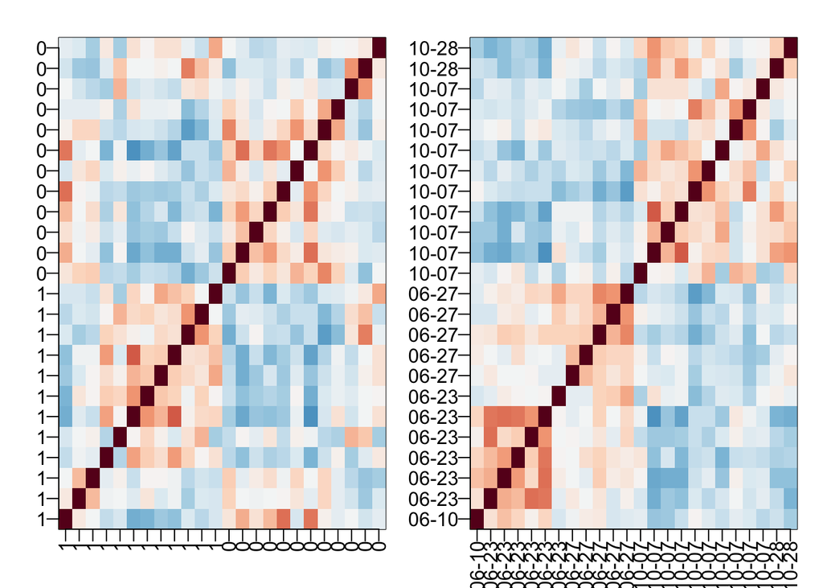

```r
library(RColorBrewer)
sex = sampleInfo$group
mypar(1,2)
cols=colorRampPalette(rev(brewer.pal(11,"RdBu")))(100)
cors = cor(y)
image(1:ncol(y),1:ncol(y),cors,col=cols,zlim=c(-1,1),
       xaxt="n",xlab="",yaxt="n",ylab="")
axis(2,1:ncol(y),sex,las=2)
axis(1,1:ncol(y),sex,las=2)
o = order(sampleInfo$date)
image(1:ncol(y),1:ncol(y),cors[o,o],col=cols,zlim=c(-1,1),
      xaxt="n",xlab="",yaxt="n",ylab="")
label = gsub("2005-","",sampleInfo$date[o])
axis(2,1:ncol(y),label,las=2)
axis(1,1:ncol(y),label,las=2)
```

##### As from the graph aboves, looking primarily at the second graph where the samples are ordered by date, the plot is ordered by we see two groups mainly driven by month, and within these we see subgroups driven by date, seems to suggest date more than month per se are the hidden factors. Therefore the answer is D).

### 4: Based on the correlation plots above, we could argue that there are at least two hidden factors. Using PCA estimate these two factors. Specifically, apply the svd to y and use the first two PCs as estimates. Which command gives us these estimates?

```r
s <- svd(y)
What <- s$v[,1:2] # these are the first two PCs.
rownames(What)<-colnames(y)
round(What,2)
```

```
##                   [,1]  [,2]
## GSM136508.CEL.gz -0.23 -0.02
## GSM136530.CEL.gz -0.03 -0.14
## GSM136517.CEL.gz -0.08 -0.19
## GSM136576.CEL.gz  0.31 -0.07
## GSM136566.CEL.gz  0.00  0.18
## GSM136574.CEL.gz  0.35 -0.09
## GSM136575.CEL.gz  0.23 -0.07
## GSM136569.CEL.gz  0.22 -0.02
## GSM136568.CEL.gz  0.29  0.00
## GSM136559.CEL.gz  0.15  0.43
## GSM136565.CEL.gz  0.11  0.23
## GSM136573.CEL.gz  0.22  0.04
## GSM136523.CEL.gz -0.14 -0.21
## GSM136509.CEL.gz -0.28  0.03
## GSM136727.CEL.gz -0.38  0.42
## GSM136510.CEL.gz -0.22 -0.05
## GSM136515.CEL.gz -0.20 -0.09
## GSM136522.CEL.gz -0.04 -0.20
## GSM136507.CEL.gz -0.29  0.00
## GSM136524.CEL.gz -0.11 -0.35
## GSM136514.CEL.gz -0.01 -0.30
## GSM136563.CEL.gz -0.03  0.20
## GSM136564.CEL.gz  0.08  0.35
## GSM136572.CEL.gz  0.10 -0.07
```

```r
fit = s$u[,1:2]%*% (s$d[1:2]*t(What))
var(as.vector(fit))/var(as.vector(y))
```

```
## [1] 0.3394245
```

##### From the code above, the answer is herefore, B) pcs = svd(y)$v[,1:2]

### 5: Plot each of the estimated factors ordered by date. Use color to denote month. The first factor is clearly related to date. Which of the following appear to be most different according to this factor?

#### A) June 23 and June 27

#### B) Oct 07 and Oct 28

#### C) June 10 and June 23

#### D) June 15 and June 24

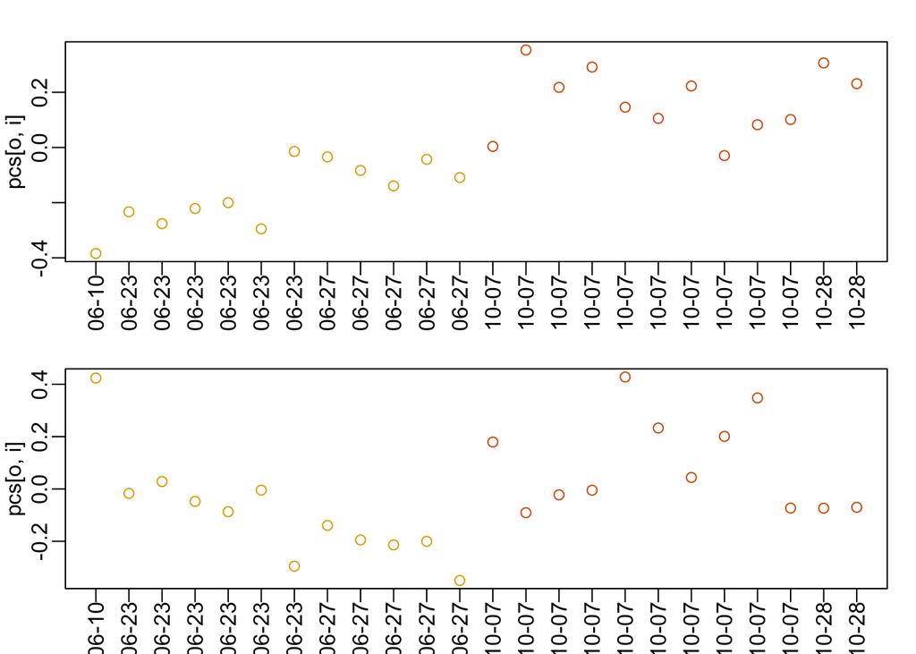

```r
month=format(sampleInfo$date, "%m")
pcs = svd(y)$v[ ,1:2]
o = order(sampleInfo$date)
cols = as.numeric(month)[o]
mypar(2,1)
for(i in 1:2){
  plot(pcs[o,i],col=cols,xaxt="n",xlab="")
  label = gsub("2005-","",sampleInfo$date[o])
  axis(1,1:ncol(y),label,las=2)
}
```

##### Based on the plot and the code above, we see that the first factor changes, so the answer is A) June 23 and June 27.

### 6: Use the svd function to obtain the principal components (PCs) for our detrended gene expression data y. How many PCs explain more than 10% of the variability?

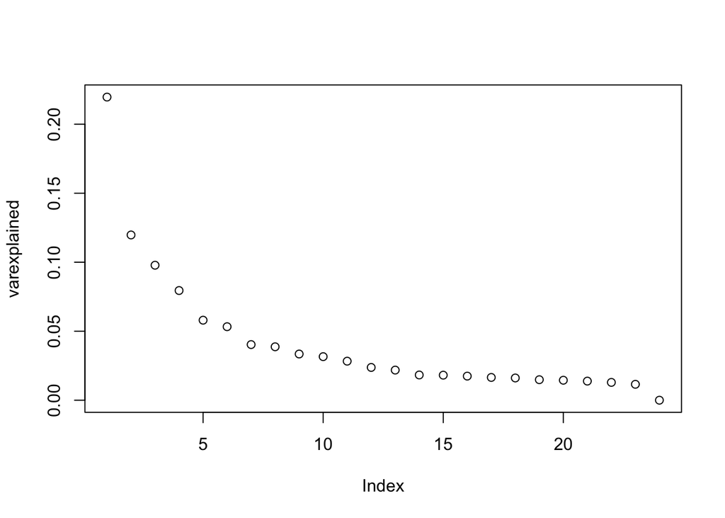

```r
s = svd(y)
varexplained = s$d^2/ sum(s$d^2)
plot(varexplained)
```

```r
sum(varexplained>0.10)
```

```
## [1] 2
```

##### From the code above 2 PC’s explain more than 10% of variability.

### 7: Which PC most correlates (negative or positive correlation) with month?

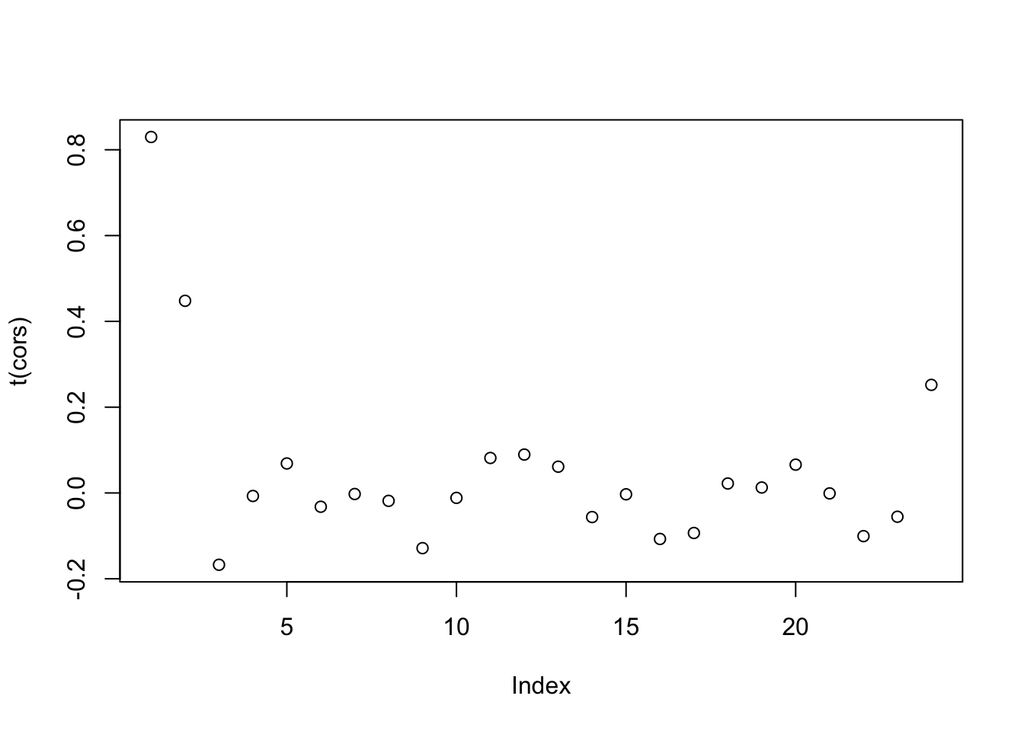

```r
s = svd(y)
month = factor( format(sampleInfo$date,"%m"))
cors = cor( as.numeric(month),s$v)
plot(t(cors))
```

```r
which.max(abs(cors))
```

```
## [1] 1
```

```r
max(abs(cors))
```

```
## [1] 0.8297915
```

##### The first PC correlates most with month.

### 8: What is this correlation (in absolute value)?

##### From the code above, we can see that the correlation (in absolute value) 0.8297915.

### 9: Which PC most correlates (negative or positive correlation) with sex?

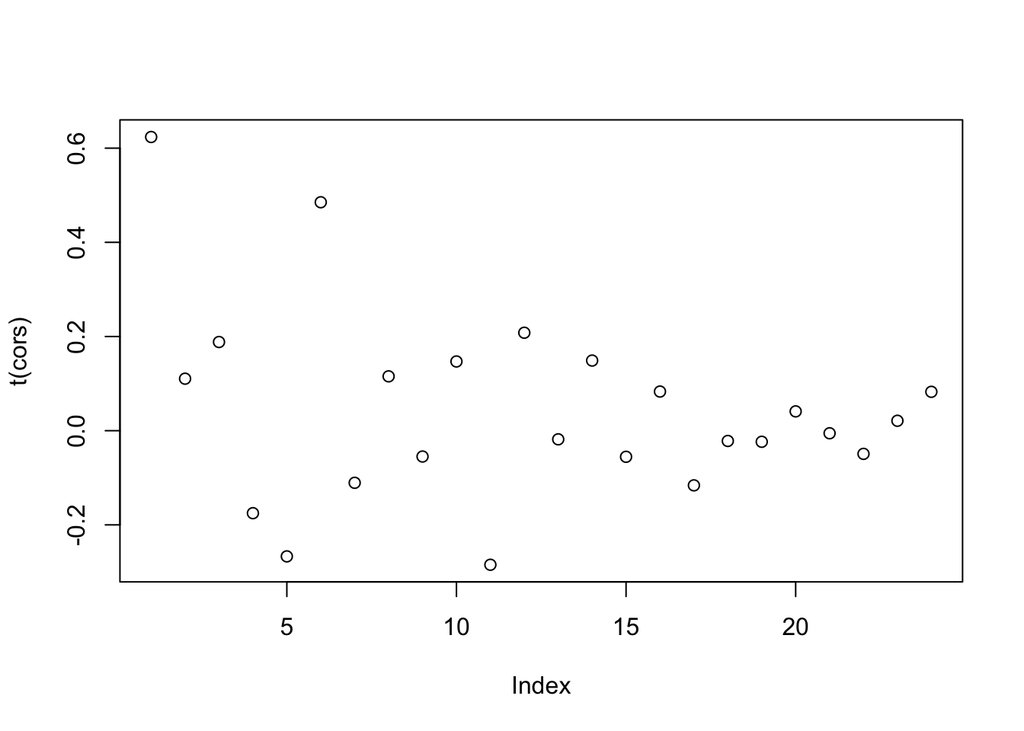

```r
s = svd(y)
sex = sampleInfo$group
cors = cor( as.numeric(sex),s$v)
plot(t(cors))
```

```r
which.max(abs(cors))
```

```
## [1] 1
```

```r
max(abs(cors))
```

```
## [1] 0.6236858
```

##### As per the code, the first PC correlates the most with sex.

### 10: What is this correlation (in absolute value)?

##### From the code above, we can see that the correlation (in absolute value) 0.6236858.

### 11: Now instead of using month, which we have shown does not quite describe the batch, add the two estimated factors s$v[,1:2] to the linear model we used above. Apply this model to each gene and compute q-values for the sex difference. How many q-values < 0.1 for the sex comparison?

```r
X <- model.matrix(~sex+s$v[,1:2])

library(limma)
X <- model.matrix(~sex+s$v[,1:2])
fit <- lmFit(y,X)
k <- 2 ##second coef, for month
ses <- fit$stdev.unscaled[,k]*fit$sigma
ttest <- fit$coef[,k]/ses
pvals <- 2*pt(-abs(ttest),fit$df)
library(qvalue)
library(genefilter)
qval = qvalue(pvals)
qvals = qval$qvalues
sum(qvals<0.1)
```

```
## [1] 14
```

##### From the computation above, there are 14 q-values that are less than 0.1.

### 12: What proportion of the genes are on chromosomes X and Y?

```r
index = geneAnnotation$CHR[qvals<0.1]%in%c("chrX","chrY")
mean(index)
```

```
## [1] 1
```

##### The proportion of the genes on chromosome X and Y are 1. Hence, all fo the genes are on chromosome X and Y.

### #Batch Effects Exercise 5:

```r
#In this section we will use the sva function in the sva package (available from Bioconductor) and apply it to the following data:
if (!requireNamespace("BiocManager", quietly = TRUE))
    install.packages("BiocManager")
BiocManager::install("sva", version = "3.8")
library(sva)
library(Biobase)
library(GSE5859Subset)
data(GSE5859Subset)
```

### 1: In a previous section we estimated factors using PCA, but we noted that the first factor was correlated with our outcome of interest:

```r
s <- svd(geneExpression-rowMeans(geneExpression))
cor(sampleInfo$group,s$v[,1])
```

```
## [1] 0.6236858
```

```r
#The svafit function estimates factors, but downweighs the genes that appear to correlate with the outcome of interest. It also tries to estimate the number of factors and returns the estimated factors like this:
sex = sampleInfo$group
mod = model.matrix(~sex)
svafit = sva(geneExpression,mod)
```

```
## Number of significant surrogate variables is:  5
## Iteration (out of 5 ):1  2  3  4  5
```

```r
head(svafit$sv)
```

```
##             [,1]        [,2]        [,3]       [,4]         [,5]
## [1,] -0.26862626 -0.03838109  0.15306742 -0.3007374  0.210098159
## [2,] -0.06132157 -0.15755769 -0.03538763  0.0851655 -0.063869257
## [3,] -0.12161818 -0.21766433 -0.12624414  0.2443445 -0.099004174
## [4,]  0.30660574 -0.09657648 -0.32034135 -0.1680430  0.620260643
## [5,] -0.01850853  0.18648507  0.17931970  0.4244993 -0.007840835
## [6,]  0.36062840 -0.08542758 -0.10726746  0.1074114  0.033204591
```

```r
#The resulting estimated factors are not that different from the PCs.
for(i in 1:ncol(svafit$sv)){
  print( cor(s$v[,i],svafit$sv[,i]) )
  }
```

```
## [1] 0.9944755
## [1] 0.9964202
## [1] -0.9915972
## [1] -0.9896597
## [1] -0.9518427
```

```r
#Now fit a linear model to each gene that instead of month includes these factors in the model. Use the qvalue function.
```

### How many genes have q-value < 0.1?

```r
svaX<-model.matrix(~sex+svafit$sv)

library(limma)
fit <- lmFit(geneExpression,svaX)
k <- 2 #second coef, for sex
ses <- fit$stdev.unscaled[,k]*fit$sigma
ttest <- fit$coef[,k]/ses
pvals <- 2*pt(-abs(ttest),fit$df)

library(qvalue)
library(genefilter)
qval = qvalue(pvals)
qvals = qval$qvalues
sum(qvals<0.1)
```

```
## [1] 13
```

##### The number of genes with a q-value less than 0.1 is 13, as per the computation above.

### 2: How many of these genes are from chrY or chrX?

```r
index = geneAnnotation$CHR[qvals<0.1]%in%c("chrX","chrY")
mean(index)
```

```
## [1] 0.9230769
```

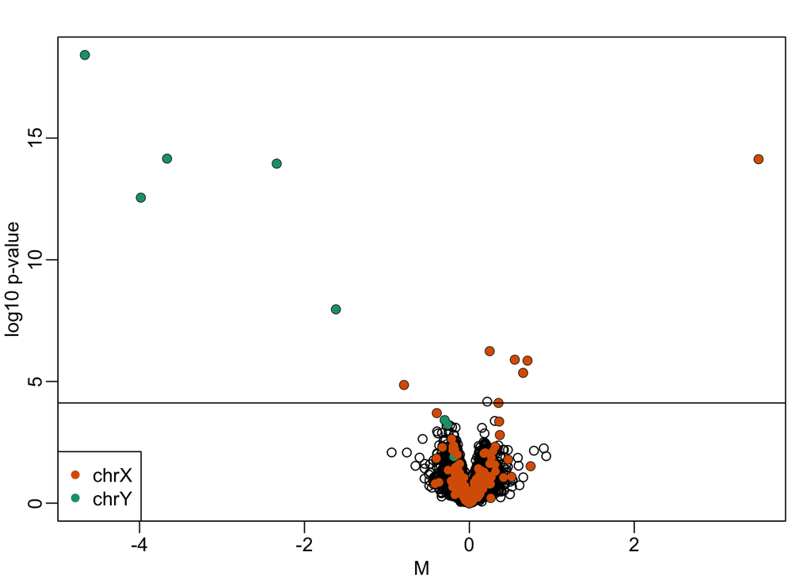

```r
#Below is the code to perform an exploratory data analysis to check the problem. I created a volcano plot:
res = sapply(1:nrow(geneExpression),function(i){
    y = geneExpression[i,]
    fit = lm(y~svaX-1)
    summary(fit)$coef[2,c(1,4)]
})

qvals = qvalue(res[2,])$qvalue
pcutoff = max( res[2,qvals < .1] )
library(rafalib)
mypar(1,1)

plot(res[1,],-log10(res[2,]),xlab="M",ylab="log10 p-value")

ind = which(geneAnnotation$CHR=="chrY")
points(res[1,ind],-log10(res[2,ind]),col=1,pch=16)

ind = which(geneAnnotation$CHR=="chrX")
points(res[1,ind],-log10(res[2,ind]),col=2,pch=16)

abline(h=-log10(pcutoff))
legend("bottomleft",c("chrX","chrY"),col=c(2,1),pch=16)
```